# Statistical Methods

Categorical Moderation

Fall 2025 | Course PSYC 790  
Jeffrey M. Girard | Lecture 11b

# Review

## Review of Last Lecture

- We learned about **moderation** via **interaction terms**
- The interaction effect is the slope of the product $x_1 x_2$
  - This allows the slope of $x_1$ to *depend on* the value of $x_2$
  - (and vice versa, slope of $x_2$ on value of $x_1$)
- We focused on interactions between *continuous* variables
  - There were infinite slopes (one for each value of $x_2$)
  - So we chose to “spotlight” just a few possible slopes

## Example moderation questions

**Continuous-by-Continuous Interaction**

- Does the effect of `duration` on `expenditure` depend on `intensity`?

**Continuous-by-Categorical Interaction**

- Does the effect of `duration` on `expenditure` depend on `sex`?

**Categorical-by-Categorical Interaction**

- Does the effect of `program` on `expenditure` depend on `sex`?

**Higher-Order Interaction**

- Does the interaction of `duration` and `intensity` depend on `sex`?

# Binary-by-Continuous

## Motivation

- Can we interact categorical and continuous predictors?
  - Yes! In fact, in some ways, it is even easier than before
  - Instead of infinite slopes, we have **one slope per category**
- Let’s moderate a continuous predictor by a binary variable
  - *Does the effect of `duration` differ by `sex`?*
  - Perhaps exercise is more “costly” for men or women…

## Adding Interaction Term

- If $x_1$ is continuous and $x_2$ is binary, we can dummy code $x_2$
  - $c_1=0$ for the reference group ($x_2=$ female)
  - $c_1=1$ for the non-reference group ($x_2=$ male)
- We will then add an interaction term $x_1 c_1$ with its own slope

$$\hat{y} = b_0 + b_1 x_1 + b_2 c_1 + b_3 x_1 c_1$$

`formula = expenditure ~ duration * sex`

## Interpreting the Coefficients

$$\hat{y} = b_0 + b_1 x_1 + b_2 c_1 + b_3 x_1 c_1$$

- $b_0$ (intercept): the predicted value of $y$ when $x_1=0$ and $c_1=0$
- $b_1$ (simple): the change in $y$ expected for a change of +1 in $x_1$ (at $c_1=0$)
- $b_2$ (simple): the difference in $y$ between the two $x_2$ groups (at $x_1=0$)
- $b_3$ (interaction): two equivalent definitions
  - the difference in $b_1$ (i.e., the slope of $x_1$) between the two $x_2$ groups
  - the difference in $b_2$ (i.e., the difference between the two $x_2$ groups) expected for a change of +1 in $x_1$

## Rearranging the Formula

$$\hat{y} = b_0 + b_1 x_1 + b_2 c_1 + b_3 x_1 c_1$$

$$\hat{y} = b_0 + (b_1 + b_3 c_1) x_1 + b_2 c_1$$

Thus, the slope of $x_1$ (its multiplier) *depends on* the $x_2$ group

Also, if there is no interaction ($b_3=0$), then $b_1$ is unchanged

The same is true for the slope of $c_1$ if we rearrange again

$$\hat{y} = b_0 + b_1 x_1 + (b_2 + b_3 x_1) c_1$$

## Interaction and Simple Effects

```r
library(tidyverse)
exercise <- read_csv("exercise.csv")

fit <- lm(expenditure ~ duration * sex, data = exercise)
model_parameters(fit)
## Parameter             | Coefficient |   SE |         95% CI | t(896) |     p
## ----------------------------------------------------------------------------
## (Intercept)           |        3.33 | 2.73 | [-2.02,  8.69] |   1.22 | 0.222
## duration              |        3.32 | 1.33 | [ 0.70,  5.93] |   2.49 | 0.013
## sex [male]            |        3.57 | 3.91 | [-4.11, 11.25] |   0.91 | 0.362
## duration × sex [male] |       -1.72 | 1.90 | [-5.45,  2.00] |  -0.91 | 0.364
```

- The interaction effect (duration $\times$ sex) is NOT significant
- Thus, the effect of `duration` does NOT depend on `sex`

## Predicting energy expenditure

$$\hat{y} = 3.33 + 3.32 x_1 + 3.57 c_1 - 1.72 x_1 x_2$$

- **Intercept:** A female participant exercising at 0 duration expends 3.33 units
- **Duration Simple Effect:** Each unit of duration will expend another 3.32 units (for females)
- **Sex Simple Effect:** Males will expend 3.57 units more than females (at 0 duration)
- **Interaction Effect:** The slope of duration will decrease by 1.72 for males, and the male–female difference will decrease by 1.72 for each added unit of duration

The average participant (2 duration) expends 9.97 units (female) or 10.1 units (male)

$$\text{Female: }\hat{y} = 3.33 + 3.32(2) + 3.57(0) - 1.72(2)(0) = 9.97$$
$$\text{Male: }\hat{y} = 3.33 + 3.32(2) + 3.57(1) - 1.72(2)(1) = 10.10$$

## Plotting interaction effects

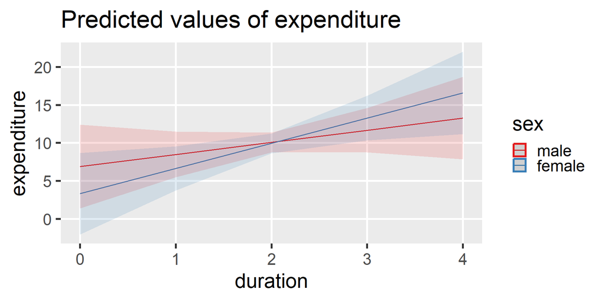

```r
library(ggeffects)
plot(predict_response(fit, terms = c("duration", "sex")))
```

You can tell there is not a significant interaction because the lines could be parallel.

## Plotting interaction effects

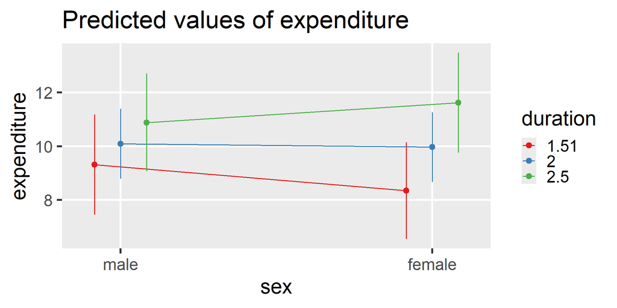

```r
plot(predict_response(fit, terms = c("sex", "duration")), connect_lines = TRUE)
```

You can still spotlight `duration` but then you lose some information.

## Simple slopes

- What is the slope of `duration` in each `sex` group?

```r
estimate_slopes(fit, trend = "duration", by = "sex")
## Estimated Marginal Effects
##
## sex    | Slope |   SE |        95% CI | t(896) |     p
## ------------------------------------------------------
## female |  3.32 | 1.33 | [ 0.70, 5.93] |   2.49 | 0.013
## male   |  1.59 | 1.35 | [-1.06, 4.24] |   1.18 | 0.240
##
## Marginal effects estimated for duration
## Type of slope was dY/dX
```

## Marginal Contrasts

- Is the `sex` difference significant at any value of `duration`?
  - Usually only do this if the interaction is significant

```r
estimate_contrasts(fit, contrast = "sex", by = "duration = [sd]")
## Marginal Contrasts Analysis
##
## Level1 | Level2 | duration | Difference |   SE |        95% CI | t(896) |     p
## -------------------------------------------------------------------------------
## male   | female |     1.51 |       0.97 | 1.33 | [-1.63, 3.58] |   0.73 | 0.464
## male   | female |     2.00 |       0.12 | 0.94 | [-1.72, 1.96] |   0.13 | 0.898
## male   | female |     2.50 |      -0.73 | 1.33 | [-3.34, 1.87] |  -0.55 | 0.580
##
## Variable predicted: expenditure
## Predictors contrasted: sex
## p-values are uncorrected.
```

## Reporting Results

> We used a linear model to regress the continuous energy expenditure variable on the continuous exercise duration variable, the binary biological sex variable (dummy coded as 0=female, 1=male), and the duration-by-sex interaction.

> The simple slope of duration was significant for females (p=.013) but not for males (p=.240) and the simple slope of sex was not significant at 0 duration (p=.362). The duration-by-sex interaction was not significant (p=.364).

## Dropping the interaction

- Unless the interaction was my main research question, I might drop a non-significant interaction and re-estimate the model to get *partial* effects (rather than simple effects)

```r
fit2 <- lm(expenditure ~ duration + sex, data = exercise)
model_parameters(fit2)
## Parameter   | Coefficient |   SE |        95% CI | t(897) |     p
## -----------------------------------------------------------------
## (Intercept) |        5.02 | 2.00 | [ 1.10, 8.95] |   2.51 | 0.012
## duration    |        2.47 | 0.95 | [ 0.60, 4.33] |   2.60 | 0.009
## sex [male]  |        0.12 | 0.94 | [-1.72, 1.96] |   0.13 | 0.899
```

# Nominal-by-Continuous

## Expanding the equation

- The same approach applies for a **nominal** moderator
  - But needs multiple dummy codes and interaction terms

$$\hat{y} = b_0 + b_1 x_1 + b_2 c_1 + b_3 c_2 + b_4 x_1 c_1 + b_5 x_1 c_2$$

`formula = expenditure ~ duration * program`

(`program` $\in\{\text{jog, swim, read}\}$ needs 2 dummy codes)

## Interpreting coefficients

$$\hat{y} = b_0 + b_1 x_1 + b_2 c_1 + b_3 c_2 + b_4 x_1 c_1 + b_5 x_1 c_2$$

- $b_0$ (intercept): expected $y$ at $x_1=0$ and $c_1=c_2=0$ (i.e., reference group)
- $b_1$ (simple): change in $y$ expected with change of +1 in $x_1$ (in reference group)
- $b_2$ (simple): difference in $y$ between reference and $c_1=1$ group (at $x_1=0$)
- $b_3$ (simple): difference in $y$ between reference and $c_2=1$ group (at $x_1=0$)
- $b_4$ (interaction): two equivalent definitions
  - difference in $b_1$ (effect of $x_1$) between reference and $c_1=1$ group
  - change in $b_2$ (effect of $c_1$) expected with change of +1 in $x_1$
- $b_5$ (interaction): two equivalent definitions
  - difference in $b_1$ (effect of $x_1$) between reference and $c_2=1$ group
  - change in $b_3$ (effect of $c_2$) expected with change of +1 in $x_1$

## Running the model

- Let’s first pick a reference group for `program`
  - `"read"` may be a good choice as it is a “control” group

```r
# reorder the levels to set "read" first (to make it the reference)
exercise$program <- factor(exercise$program, levels = c("read", "jog", "swim"))

fit3 <- lm(expenditure ~ duration * program, data = exercise)

model_parameters(fit3)
## Parameter                 | Coefficient |   SE |          95% CI | t(894) |      p
## ----------------------------------------------------------------------------------
## (Intercept)               |        2.22 | 1.49 | [ -0.70,  5.13] |   1.49 | 0.136
## duration                  |       -2.96 | 0.71 | [ -4.35, -1.57] |  -4.18 | < .001
## program [jog]             |       -9.00 | 2.22 | [-13.35, -4.65] |  -4.06 | < .001
## program [swim]            |        9.93 | 2.18 | [  5.66, 14.21] |   4.56 | < .001
## duration × program [jog]  |       10.41 | 1.07 | [  8.30, 12.51] |   9.71 | < .001
## duration × program [swim] |        9.83 | 1.05 | [  7.77, 11.89] |   9.35 | < .001
```

## Plotting the interaction

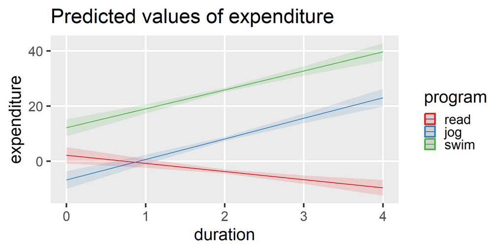

```r
plot(predict_response(fit3, terms = c("duration", "program")))
```

## Plotting the interaction

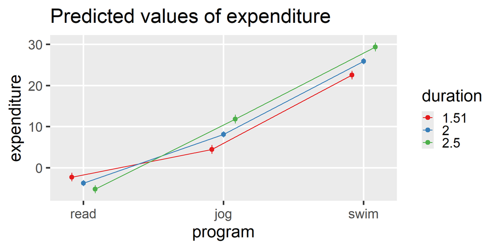

```r
plot(predict_response(fit3, terms = c("program", "duration")), connect_lines = TRUE)
```

## Centering

- Do we really care about effects at zero duration?
  - If not, the simple effects’ tests are not interesting
- We may prefer to center `duration` instead
  - Now the simple effects’ tests are at the *average* duration

```r
options(width = 300)
```

```r
fit4 <- lm(expenditure ~ center(duration) * program, data = exercise)
model_parameters(fit4)
## Parameter                         | Coefficient |   SE |         95% CI | t(894) |      p
## -----------------------------------------------------------------------------------------
## (Intercept)                       |       -3.70 | 0.38 | [-4.44, -2.97] |  -9.85 | < .001
## center(duration)                  |       -2.96 | 0.71 | [-4.35, -1.57] |  -4.18 | < .001
## program [jog]                     |       11.85 | 0.53 | [10.80, 12.89] |  22.29 | < .001
## program [swim]                    |       29.62 | 0.53 | [28.57, 30.66] |  55.73 | < .001
## center(duration) × program [jog]  |       10.41 | 1.07 | [ 8.30, 12.51] |   9.71 | < .001
## center(duration) × program [swim] |        9.83 | 1.05 | [ 7.77, 11.89] |   9.35 | < .001
```

## Probing the interaction

```r
estimate_slopes(fit4, trend = "duration", by = "program")
## Estimated Marginal Effects
##
## program | Slope |   SE |         95% CI | t(894) |      p
## ---------------------------------------------------------
## read    | -2.96 | 0.71 | [-4.35, -1.57] |  -4.18 | < .001
## jog     |  7.45 | 0.81 | [ 5.87,  9.03] |   9.25 | < .001
## swim    |  6.87 | 0.78 | [ 5.35,  8.40] |   8.84 | < .001
##
## Marginal effects estimated for duration
## Type of slope was dY/dX
```

## Probing the interaction

```r
estimate_contrasts(fit4, contrast = "program", by = "duration = [sd]",
                   p_adjust = "holm")
## Marginal Contrasts Analysis
##
## Level1 | Level2 | duration | Difference |   SE |         95% CI | t(894) |      p
## ---------------------------------------------------------------------------------
## jog    | read   |     1.51 |       6.70 | 0.75 | [ 5.22,  8.18] |   8.89 | < .001
## swim   | read   |     1.51 |      24.76 | 0.75 | [23.29, 26.22] |  33.12 | < .001
## swim   | jog    |     1.51 |      18.06 | 0.76 | [16.57, 19.54] |  23.91 | < .001
## jog    | read   |     2.00 |      11.84 | 0.53 | [10.80, 12.88] |  22.28 | < .001
## swim   | read   |     2.00 |      29.61 | 0.53 | [28.57, 30.66] |  55.73 | < .001
## swim   | jog    |     2.00 |      17.77 | 0.53 | [16.73, 18.81] |  33.46 | < .001
## jog    | read   |     2.50 |      16.99 | 0.75 | [15.53, 18.46] |  22.73 | < .001
## swim   | read   |     2.50 |      34.48 | 0.74 | [33.03, 35.93] |  46.63 | < .001
## swim   | jog    |     2.50 |      17.48 | 0.78 | [15.96, 19.01] |  22.45 | < .001
##
## Variable predicted: expenditure
## Predictors contrasted: program
## p-value adjustment method: Holm (1979)
```

# Categorical-by-Categorical

## Expanding the equation

- We can also interact two categorical variables
- We need two sets of dummy codes (e.g., $[c_1]$ and $[d_1,d_2]$)

$$\hat{y} = b_0 + b_1 c_1 + b_2 d_1 + b_3 d_2 + b_4 c_1 d_1 + b_5 c_1 d_2$$

`expenditure ~ sex + program + sex:program`

## Simple and interaction effects

```r
fit5 <- lm(expenditure ~ sex * program, data = exercise)
model_parameters(fit5)
## Parameter                   | Coefficient |   SE |         95% CI | t(894) |      p
## -----------------------------------------------------------------------------------
## (Intercept)                 |       -3.62 | 0.53 | [-4.66, -2.58] |  -6.80 | < .001
## sex [male]                  |       -0.34 | 0.75 | [-1.81,  1.14] |  -0.45 | 0.656
## program [jog]               |        7.91 | 0.75 | [ 6.43,  9.39] |  10.51 | < .001
## program [swim]              |       32.74 | 0.75 | [31.26, 34.22] |  43.49 | < .001
## sex [male] × program [jog]  |        7.82 | 1.06 | [ 5.73,  9.91] |   7.35 | < .001
## sex [male] × program [swim] |       -6.26 | 1.06 | [-8.35, -4.17] |  -5.88 | < .001
```

## Estimating means

```r
estimate_means(fit5, by = c("sex", "program"))
## Estimated Marginal Means
##
## sex    | program |  Mean |   SE |         95% CI | t(894)
## ---------------------------------------------------------
## female | read    | -3.62 | 0.53 | [-4.66, -2.58] |  -6.80
## male   | read    | -3.96 | 0.53 | [-5.00, -2.91] |  -7.43
## female | jog     |  4.29 | 0.53 | [ 3.24,  5.33] |   8.06
## male   | jog     | 11.77 | 0.53 | [10.73, 12.82] |  22.12
## female | swim    | 29.12 | 0.53 | [28.07, 30.16] |  54.71
## male   | swim    | 22.52 | 0.53 | [21.48, 23.57] |  42.32
##
## Variable predicted: expenditure
## Predictors modulated: sex, program
```

## Estimating contrasts

```r
estimate_contrasts(fit5, contrast = "sex", by = "program")
## Marginal Contrasts Analysis
##
## Level1 | Level2 | program | Difference |   SE |         95% CI | t(894) |      p
## --------------------------------------------------------------------------------
## male   | female | read    |      -0.34 | 0.75 | [-1.81,  1.14] |  -0.45 |  0.656
## male   | female | jog     |       7.48 | 0.75 | [ 6.01,  8.96] |   9.94 | < .001
## male   | female | swim    |      -6.60 | 0.75 | [-8.07, -5.12] |  -8.76 | < .001
##
## Variable predicted: expenditure
## Predictors contrasted: sex
## p-values are uncorrected.
```

## Estimating contrasts

```r
estimate_contrasts(fit5, contrast = "program", by = "sex")
## Marginal Contrasts Analysis
##
## Level1 | Level2 | sex    | Difference |   SE |         95% CI | t(894) |      p
## -------------------------------------------------------------------------------
## jog    | read   | female |       7.91 | 0.75 | [ 6.43,  9.39] |  10.51 | < .001
## swim   | read   | female |      32.74 | 0.75 | [31.26, 34.22] |  43.49 | < .001
## swim   | jog    | female |      24.83 | 0.75 | [23.35, 26.31] |  32.99 | < .001
## jog    | read   | male   |      15.73 | 0.75 | [14.25, 17.20] |  20.89 | < .001
## swim   | read   | male   |      26.48 | 0.75 | [25.00, 27.96] |  35.18 | < .001
## swim   | jog    | male   |      10.75 | 0.75 | [ 9.27, 12.23] |  14.28 | < .001
##
## Variable predicted: expenditure
## Predictors contrasted: program
## p-values are uncorrected.
```

## Plotting the interaction

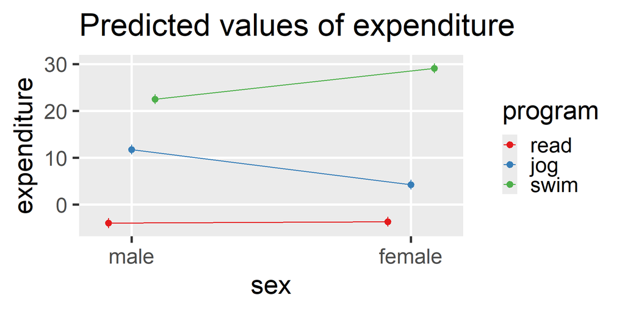

```r
plot(predict_response(fit5, terms = c("sex", "program")), connect_lines = TRUE)
```

## Plotting the interaction

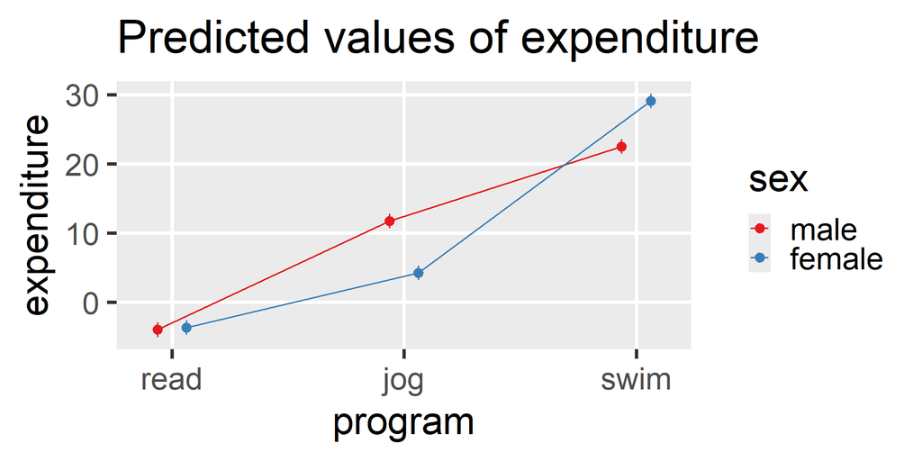

```r
plot(predict_response(fit5, terms = c("program", "sex")), connect_lines = TRUE)
```